# Introduction to R: Session 2

### 4.1.2 Map data to plot aesthetics

Next, we need to tell R which variables (i.e. which columns) of our data we want to plot. To do this, we map column names from our data to plot aesthetics (features), such as the x and y axes.

⭐ We map variables to aesthetics inside the `aes()` function, and assign this to the `mapping` argument of the `ggplot()` function.

In the following code, we map the column “health_expenditure_usd” to the x-axis, and “life_expectancy_years” to the y-axis:

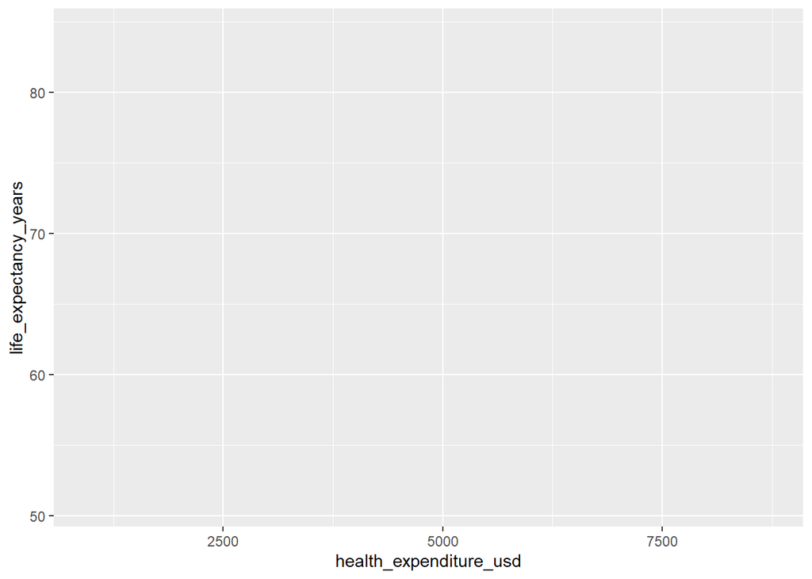

```r
ggplot(data = life_expectancy,
       mapping = aes(x = health_expenditure_usd,
                     y = life_expectancy_years))
```

💻 Copy and paste the code above into your R Studio console and run it.

The variables will now appeared on their respective axes, and there are numbers indicating the range of the values. But there is no data yet because we still need to tell R *how* to plot the data (step 3).

### 4.1.3 Define the plot type

Finally, we need to tell R *how* to plot our chosen data and variables.

⭐ We define the plot type with a `geom_` function.

⭐ We add the chosen `geom_` function by writing a plus symbol (`+`) after the end of the `ggplot()` function.

In the following code, we add the `geom_point()` function to make a scatter plot:

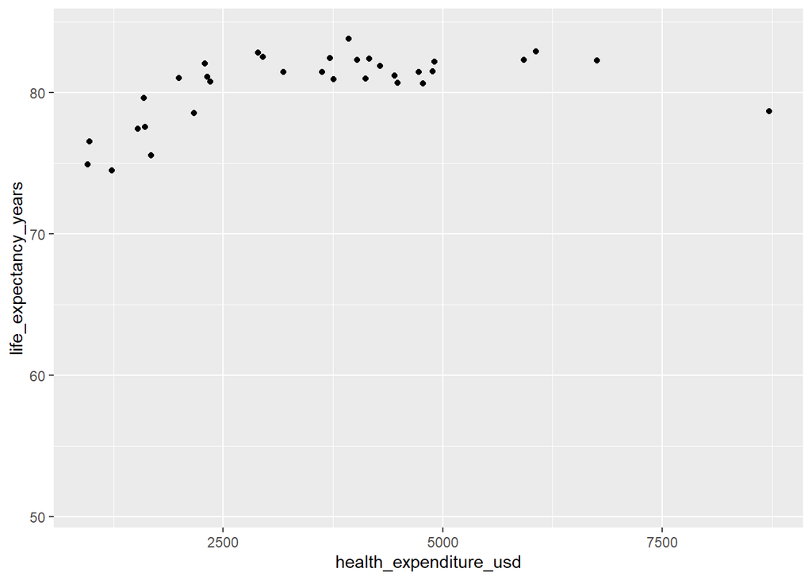

```r
ggplot(data = life_expectancy,
       mapping = aes(x = health_expenditure_usd,
                     y = life_expectancy_years)) +
  geom_point()
```

💻 Copy and paste the code above into your R Studio console and run it.

Congratulations, you’ve made your first plot in R! The `geom_point()` function adds points to the plot. Each point represents a row in the data `life_expectancy` where neither health expenditure nor life expectancy are missing.

❓ There are many different “geoms” available, each for a different plot type. Look at some of the different plots on the [The R graph gallery](https://r-graph-gallery.com/). What are the names of some other “geom” functions?

## 4.2 Example 1: scatter plot

In this section, we will walk through the steps to make the following plot. The plot shows of country-level life expectancy at birth in years versus health expenditure per capita in USD for 33 countries:

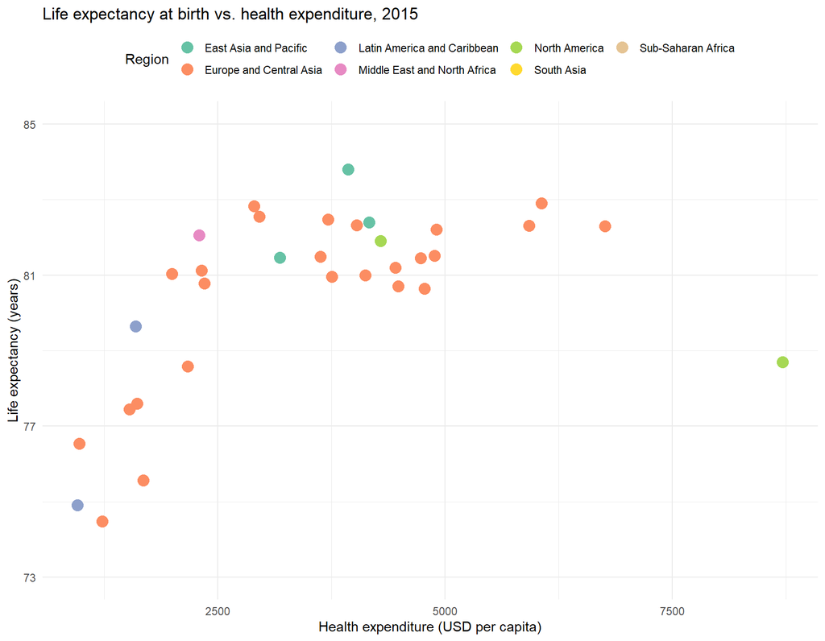

The code to make this plot will begin with the code we saw in the previous section.

💻 Copy and paste the following code into your R script.

```r
ggplot(data = life_expectancy,
       mapping = aes(x = health_expenditure_usd,
                     y = life_expectancy_years)) +
  geom_point()
```

### 4.2.1 Change the size, shape and colour of points

First, we look at how to change the size, shape and colour of the points in a scatter plot.

#### Fixed size, shape and colour

⭐ We can change the fixed attribute of the points by setting the arguments `size`, `shape` and `colour` inside the geom function.

In the following code we set the point size to 10, the shape to a diamond and the colour to “hotpink”:

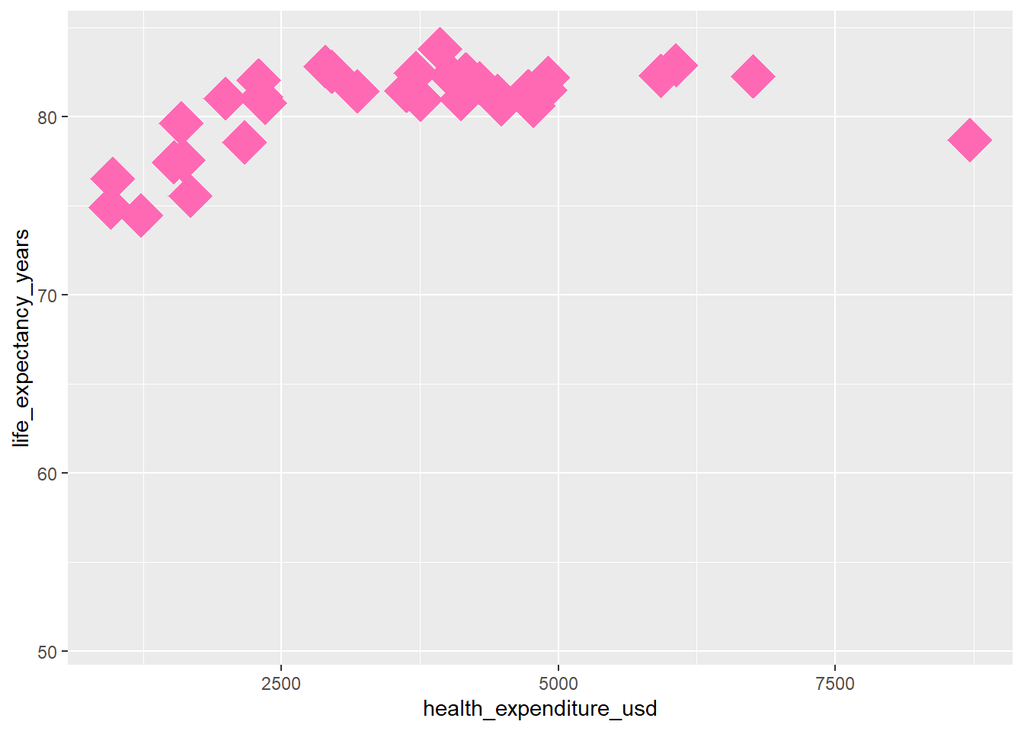

```r
ggplot(data = life_expectancy,
       mapping = aes(x = health_expenditure_usd,
                     y = life_expectancy_years)) +
  geom_point(size = 10, shape = "diamond", color = "hotpink")
```

- The `size` argument changes the size of the points. The argument takes positive numeric values, where bigger values equate to bigger points.
- The `shape` argument changes the shape of the points. This [ggplot2 vignette](https://ggplot2.tidyverse.org/articles/ggplot2-specs.html#sec:shape-spec) has more details about the values that this argument can take.

❓ Read the ggplot2 vignette section about `shape`. What other values can this take?

- The `color` argument changes the colour of the points. The argument takes values from the output of the `colors()` function.

❓ Run the `colours()` function in your R Studio console. What other values can this take?

💻 Edit the code in your R script to change the default size, shape and colour of the points.

#### Dynamic colours

⭐ We can change the colour of the points according to values in the data by mapping a column name to the `colour` aesthetic inside the `aes()` function.

In the following code, we map the column “region” to the `colour` argument:

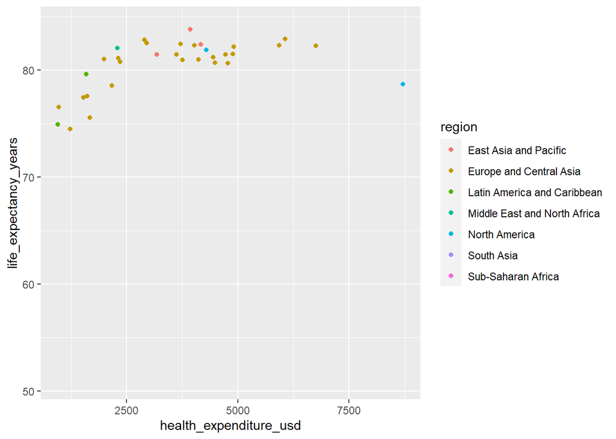

```r
ggplot(data = life_expectancy,
       mapping = aes(x = health_expenditure_usd,
                     y = life_expectancy_years,
                     colour = region)) +
  geom_point()
```

### 4.2.2 Other optional plot changes

In this section we look at how to do the following:

- Change the limits and breaks on a numeric axis
- Change the colour palette
- Add axis labels and a title
- Change the plot theme (general appearance)
- Move the legend

💻 Copy and paste the code below into a script in your R Studio session.

```r
ggplot(data = life_expectancy,
       mapping = aes(x = health_expenditure_usd,
                     y = life_expectancy_years,
                     col = region)) +
  geom_point(size = 4, shape = "diamond") +

  # Update the y-axis limits and breaks
  scale_y_continuous(limits = c(60, 90),
                     breaks = seq(from = 60, to = 90, by = 10)) +

  # Update the colour palette
  scale_color_brewer(palette = "Set2") +

  # Add axis labels, legend title (color) and plot title
  labs(x = "health_expenditure_usd",
       y = "life_expectancy_years",
       color = "Region",
       title = "My first ggplot!") +

  # Update the theme
  theme_minimal() +

  # Move the legend
  theme(legend.position = "right")
```

#### Change the limits and breaks on a numeric axis

⭐ Use the `scale_y_continuous()` function to change a numeric y axis.

We can update the limits using the `limits` argument, and we can update the breaks using the `breaks` argument.

In the code above, the y-axis lower and upper limits are 60 and 90, respectively (`limits = c(60, 90)`), and the axis breaks start at 60, end at 90 and increase by 10 (`breaks = seq(from = 60, to = 90, by = 10)`).

💻 Edit your code to make the following changes to the y-axis limits and breaks: change the y-axis lower limit to 73 and the upper limit to 85, and change the y-axis breaks to start at 73, end at 85 and increase by 4.

#### Change the colour palette

Use the `scale_color_brewer()` function to change the colour palette used for a dynamic colour aesthetic.

We can choose an appropriate palette by defining the `palette` argument.

❓ Read the documentation for `scale_color_brewer()`. What are the names of some of the other qualitative palettes available?

#### Change axis labels and add a plot title

⭐ Use the `labs()` function to define axis labels, the plot title, and more.

The arguments `x` and `y` define the x- and y-axis labels, respectively, while the `title` argument defines the plot title.

In the code above, the x-axis title is `"health_expenditure_usd"`, the y-axis title is `"life_expectancy_years"`, and the title of the plot is `"My first ggplot!"`.

💻 Edit your code to give the x-axis, y-axis and plot title more informative values. If you’re stuck on *what* to write, you can refer to the plot at the start of the section if you want to, or you can choose your text values.

❓ Run `?labs()` in your R Studio console and read the documentation. What other text can you add or edit with the `labs()` function?

#### Change the plot theme

⭐ One of the easiest ways to make changes to the general design of a plot is with a complete theme, using a function of the format `theme_()`.

A complete theme will adjust many of the features of the plot, such as the background colour, the axes, whether there are gridlines or not, and text size, colour and font. One example of a complete theme is the function `theme_minimal()`.

💻 Read the ggplot2 documentation page about [complete themes](https://ggplot2.tidyverse.org/reference/ggtheme.html). Edit your code to try some other complete themes.

#### Change the legend position

⭐ Individual elements of the plot appearance can be adjusted within the `theme()` function. For example, we can move the legend position with `legend.position` argument.

In the code above, the legend is on the `"right"`.

💻 Edit your code to move the legend to the `"top"` or `"bottom"` of the plot.

## 4.3 Example 2: histogram

We are going to walk you through the steps to make this histogram of life expectancy at birth by region, using the data in `life_expectancy`:

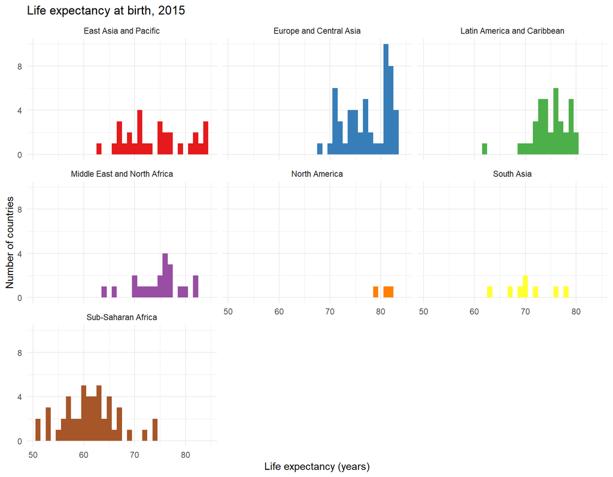

### 4.3.1 Change the bin width

We can change the width of the histogram bins (bars) with the `binwidth` argument.

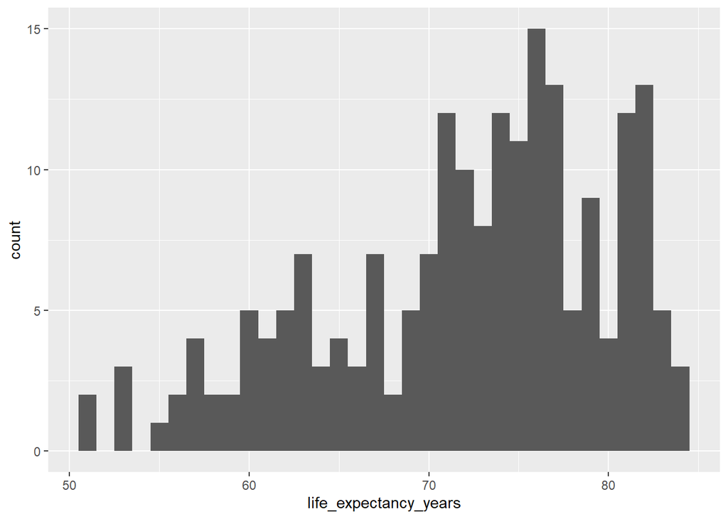

```r
ggplot(data = life_expectancy,
       mapping = aes(x = life_expectancy_years)) +
  geom_histogram(binwidth = 1)
```

💻 What happens to the output of this code as you increase or decrease the value of `binwidth`?

### 4.3.2 Change the color and fill of bars

#### Fixed color and fill

⭐ We can change the fixed attribute of the bars by setting the arguments `colour` and `fill` inside the geom function.

In the following code we set the colour (colour of the bar outline) to `"seagreen"` and the fill (colour of the bar inside) to `"tomato"`:

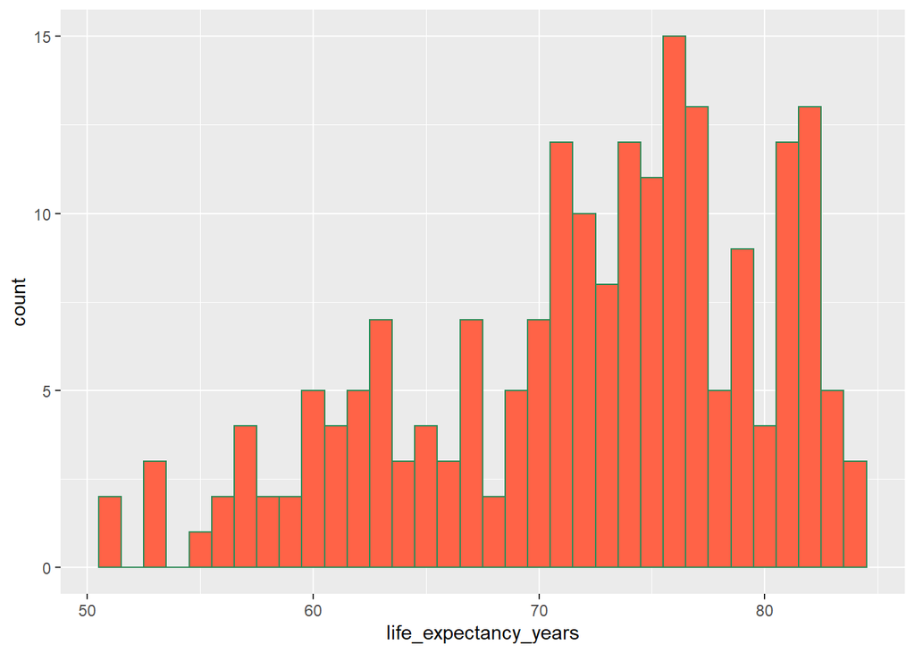

```r
ggplot(data = life_expectancy,
       mapping = aes(x = life_expectancy_years)) +
  geom_histogram(binwidth = 1, colour = "seagreen", fill = "tomato")
```

#### Dynamic fill

⭐ We can change the fill of the bars according to values in the data by mapping a column name to the `fill` aesthetic inside the `aes()` function.

In the following code, we map the column “region” to the `fill` argument:

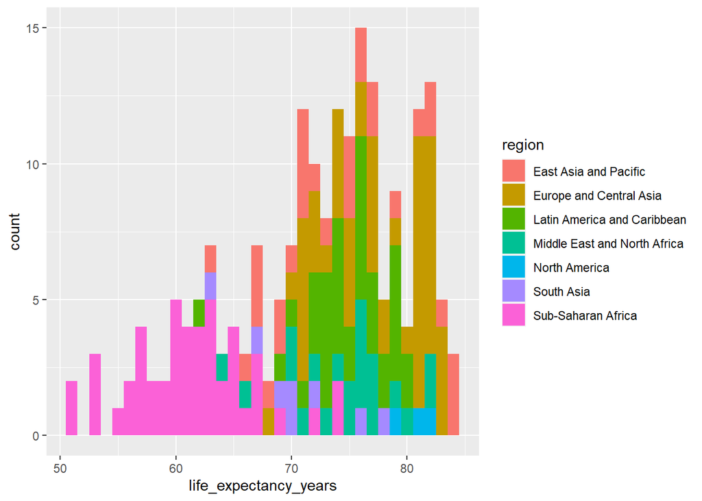

```r
ggplot(data = life_expectancy,
       mapping = aes(x = life_expectancy_years,
                     fill = region)) +
  geom_histogram(binwidth = 1)
```

### 4.3.3 Other optional plot changes

We are going to cover how to:

- Break a plot into subplots (facets)
- Change the fill colour palette
- Remove the legend

You will also see the same functions used earlier to change the y-axis scale, to add axis labels and a plot title, and to change the theme.

💻 Copy and paste the code below into a script in your R Studio session.

```r
ggplot(data = life_expectancy,
         mapping = aes(x = life_expectancy_years,
                       fill = region)) +
  geom_histogram(binwidth = 1) +

  # Divide the plot into subplots (facets)
  facet_wrap(~ region) +

  # Update the y-axis limits and breaks
  scale_y_continuous(breaks = seq(from = 0, to = 16, by = 4)) +

  # Update the fill colour palette
  scale_fill_brewer(palette = "Accent") +

  # Add axis labels, legend title (fill), and plot title
  labs(x = "Life expectancy (years)",
       y = "Number of countries",
       fill = "Region",
       title = "Life expectancy at birth, 2015") +

  # Update the theme
  theme_minimal() +

  # Remove the legend
  theme(legend.position = "none")
```

#### Break a plot into subplots

“Facets” are used to split one plot into a multi-panel figure, where each subplot represents a subgroup of the data.

⭐ Use the `facet_wrap()` function to split the main plot into multiple subplots.

The command `facet_wrap(~ region)` splits the plot into a subplot for each region in the data.

#### Change the colour palette

Use the `scale_fill_brewer()` function to change the colour palette used for a dynamic fill aesthetic. This is very similar to the `scale_color_brewer()` function you saw in the first example. Again, we can choose an appropriate palette by defining the `palette` argument.

#### Change the legend position

⭐ We saw in the first example that we can move the legend position with `legend.position` argument. To remove the legend completely, we set `legend.position = "none"`.

## 4.4 Make your own plot!

Look again at the `life_expectancy` data and try making your own plot. You could use a plot type we’ve already seen, or look at how to make a new one in the [The R graph gallery](https://r-graph-gallery.com/).

# 5 Bonus: Data manipulation with the dplyr package

In the same way that `ggplot` is an extremely useful extension to generate figures, `dplyr` is designed to facilitate cleaning and manipulating data. It contains different functions that can select, rename and add columns, filter observations of interest, or summarise the data imported in R, without changing the source data file.

In this bonus section, we will run present a few of these functions by applying them to our data `life_expectancy`. But first, let’s install and import `dplyr`.

```r
## Install the dplyr package
install.packages("dplyr")
```

```r
## Import dplyr
library(dplyr)
```

## 5.1 Filtering rows

Firstly, when doing data analysis, or data cleaning, you may want to focus only on certain observations (e.g. observations collected in a setting of interest, or extreme observations). To do so, the function `filter` will return rows than fulfill a certain condition. For instance, if we were only interested in certain entries of our life expectancy dataset:

```r
filter(life_expectancy,
       region == "North America")
```

| region | country | pop_100k | life_expectancy_years | health_expenditure_usd |
| --- | --- | --- | --- | --- |
| North America | Bermuda | 0.63165 | 81.01219 | NA |
| North America | Canada | 357.32120 | 81.90000 | 4288.992 |
| North America | United States | 3246.07776 | 78.69025 | 8714.897 |

```r
filter(life_expectancy,
       life_expectancy_years < 55)
```

| region | country | pop_100k | life_expectancy_years | health_expenditure_usd |
| --- | --- | --- | --- | --- |
| Sub-Saharan Africa | Central African Republic | 48.19341 | 50.881 | NA |
| Sub-Saharan Africa | Chad | 141.40277 | 53.137 | NA |
| Sub-Saharan Africa | Lesotho | 21.18532 | 51.038 | NA |
| Sub-Saharan Africa | Nigeria | 1839.95776 | 53.112 | NA |
| Sub-Saharan Africa | Sierra Leone | 73.14779 | 52.941 | NA |

⭐ The first argument of the `dplyr` functions indicates the dataset we are using (`life_expectancy`).

In the first command, we select only entries where the column `region` is `North America`, whereas in the second example, we selected entries where `life_expectancy_years` was below 55.

❓ Check the entries selected when running the second command, can you see any entry where the life expectancy is `NA` (i.e. not reported)? How does `dplyr` deal with missing entries when selecting rows?

## 5.2 Renaming columns

The function `rename` can be use to edit the column names of your dataset. This can be especially useful when the names are too long (and make the code cluttered), or unclear.

```r
life_expectancy <- rename(life_expectancy,
                          le_years = life_expectancy_years,
                          he_usd = health_expenditure_usd)
```

In this example, we changed the name of the columns `life_expectancy_years` to `le_years`, and `health_expenditure_usd` to `he_usd`. That will make future lines of code a bit shorter, without affecting the clarity of the column names.

## 5.3 Mutating columns

Some columns may not be in the format we expect, or may too much detail. For instance, we can round the column `le_years` (indicating the life expectancy per country) to only indicate the rounded number of years of life expectancy.

⭐ To edit the value of certain columns in our data, we use the function `mutate`.

```r
life_expectancy <- mutate(life_expectancy,
                          le_years = round(le_years, 0))
```

## 5.4 Selecting columns

In our current example, `life_expectancy` contains only five columns. However, when working with large-scale datasets, the number of columns in your data can be much bigger.

⭐ The command `select` can be used to pick the columns of interest for our analysis, and drop the irrelevant ones.

```r
select(life_expectancy,
       country, he_usd)
```

|  | country | he_usd |
| --- | --- | --- |
| 1 | Afghanistan | NA |
| 2 | Albania | NA |
| 3 | Algeria | NA |
| 4 | American Samoa | NA |
| 5 | Andorra | NA |
| 6 | Angola | NA |
| 7 | Antigua and Barbuda | NA |
| 8 | Argentina | NA |
| 9 | Armenia | NA |
| 10 | Aruba | NA |

[output cut: 207 more lines]

In this example, we only selected the columns `country`, and `he_usd`.